# An overview of Difference-in-Difference and Synthetic Control Methods: Classical and Novel Approaches

Society for Epidemiologic Research (SER) Workshop: |  
Synthetic control methods and related designs: Part 3/4

Tarik Benmarhnia https://profiles.ucsd.edu/tarik.benmarhnia (UCSD & Scripps Institute)https://benmarhniaresearch.ucsd.edu/ , Roch Nianogo https://ph.ucla.edu/about/faculty-staff-directory/roch-nianogo (Department of Epidemiology, UCLA Fielding School of Public Health)https://ph.ucla.edu/about/faculty-staff-directory/roch-nianogo  
April 22th 2024

# Loading the data

Let’s load the data

```r
mydata <- read_csv(here("data", "sim_data.csv"))
```

You can either use the data that we modified before in part 1 or you can modify the the raw data here

```r
year_policy <- 2000

mydata <- mydata %>%
  mutate(year_rec = year - year_policy,
         post     = ifelse(year>=year_policy,1,0),
         treated  = ifelse(state %in% c("Alabama",  "Alaska",
                                        "Arizona", "Arkansas", "California"), 1,0),
         treatedpost = treated*post)
```

# Traditional Synthetic Control Method (Abadie)

The data needs to be a data.frame (as opposed to a tibble) to be able to be used in the `Synth` package. To that extent one can use the `as.data.frame()` command

```r
mydata <- mydata %>%
  mutate(year_rec = as.integer(year_rec)) %>%
  as.data.frame() # need to convert to a data.frame for some function to work

# create a list of treated states
list_int <- mydata %>%
  filter(treated==1) %>%
  select(state_num) %>%
  distinct() %>%
  as.matrix() %>%
  as.vector()
list_int
```

```
[1] 1 2 3 4 5
```

```r
# create a list of control states
list_control <- mydata %>%
  filter(treated==0) %>%
  select(state_num) %>%
  distinct() %>%
  as.matrix() %>%
  as.vector()
list_control
```

```
 [1]  6  7  8  9 10 11 12 13 14 15 16 17 18 19 20 21 22 23 24 25 26 27
[23] 28 29 30 31 32 33 34 35 36 37 38 39 40 41 42 43 44 45 46 47 48 49
[45] 50
```

```r
# create some handy object to be used in the Synth package
year_start  = 1961
year_end    = 2010
year_policy = 2000
year_policy_prior = year_policy - 1
```

## Step 1: Prep the data

```r
p_load("Synth")
dataprep.out <-
  dataprep(foo = mydata,
           predictors = c("xit"), #include time-varying and unit-varying variables
           predictors.op = "mean",
           dependent     = "y",
           unit.variable = "state_num",
           time.variable = "year",
           unit.names.variable = "state",
           treatment.identifier  = 1, #cannot be several states
           controls.identifier   = list_control,
           time.predictors.prior = c(year_start:year_policy_prior),
           time.optimize.ssr     = c(year_start:year_policy_prior),
           time.plot             = c(year_start:year_end))
```

## Step 2: Obtain the weights

```r
#-Run the Synth command
synth.out <- synth(dataprep.out)
```

```
X1, X0, Z1, Z0 all come directly from dataprep object.


****************
 optimization over w weights: computing synthtic control unit



****************
****************
****************

MSPE (LOSS V): 164.3928

solution.v:
 1

solution.w:
 0.0109946 0.0114895 0.008847597 0.000574016 0.573475 0.00794255 0.01312014 0.01062103 0.01599559 0.01434792 0.007919763 0.01127531 0.004697939 0.01464977 0.006709016 0.03731697 0.002420709 0.006695522 0.0144069 0.012142 0.006136021 0.004507521 0.009847342 0.008949787 0.002050807 0.009219978 0.01011…
```

```r
#Get result tables
print(synth.tables   <- synth.tab(
  dataprep.res = dataprep.out,
  synth.res    = synth.out)
)
```

```
$tab.pred
    Treated Synthetic Sample Mean
xit   24.23    24.229       3.596

$tab.v
    v.weights
xit         1

$tab.w
   w.weights     unit.names unit.numbers
6      0.011       Colorado            6
7      0.011    Connecticut            7
8      0.009       Delaware            8
9      0.001        Florida            9
10     0.573        Georgia           10
```

[output cut: 44 more lines]

```r
#See thee weights
round(synth.out$solution.w,2)
```

```
   w.weight
6      0.01
7      0.01
8      0.01
9      0.00
10     0.57
11     0.01
12     0.01
13     0.01
14     0.02
15     0.01
16     0.01
17     0.01
18     0.00
19     0.01
```

[output cut: 31 more lines]

```r
sum(synth.out$solution.w)
```

```
[1] 1
```

## Step 3: Obtain the estimate using a DID

```r
##--Estimate the average (weighted) outcome in the synthetic control prior to the policy

y_ctrl_pre <- dataprep.out$Y0plot%*%synth.out$solution.w %>%
  as.data.frame() %>%
  rownames_to_column(var="year") %>%
  rename(control=w.weight) %>%
  filter(year %in% c(year_start:year_policy_prior)) %>%
  group_by() %>%
  summarise(mean=mean(control)) %>%
  as.matrix() %>%
  as.vector()
y_ctrl_pre
```

```
[1] 116.4011
```

```r
##--Estimate the average (weighted) outcome in the synthetic control after the policy
y_ctrl_post <- dataprep.out$Y0plot%*%synth.out$solution.w %>%
  as.data.frame() %>%
  rownames_to_column(var="year") %>%
  rename(control=w.weight) %>%
  filter(year %in% c(year_policy:year_end)) %>%
  group_by() %>%
  summarise(mean=mean(control)) %>%
  as.matrix() %>%
  as.vector()
y_ctrl_post
```

```
[1] 255.9511
```

```r
##--Estimate the average outcome in the treated state prior to the policy
y_treat_pre <- dataprep.out$Y1plot %>%
  as.data.frame() %>%
  rownames_to_column(var="year") %>%
  rename(treated=`1`) %>%
  filter(year %in% c(year_start:year_policy_prior)) %>%
  group_by() %>%
  summarise(mean=mean(treated)) %>%
  as.matrix() %>%
  as.vector()
y_treat_pre
```

```
[1] 129.1608
```

```r
##--Estimate the average outcome in the treated state after the policy
y_treat_post <- dataprep.out$Y1plot %>%
  as.data.frame() %>%
  rownames_to_column(var="year") %>%
  rename(treated=`1`) %>%
  filter(year %in% c(year_policy:year_end)) %>%
  group_by() %>%
  summarise(mean=mean(treated)) %>%
  as.matrix() %>%
  as.vector()
y_treat_post
```

```
[1] 368.678
```

```r
##--Estimate a simple difference-in-difference
diff_post = y_treat_post - y_ctrl_post
diff_pre = y_treat_pre - y_ctrl_pre
diff_pre
```

```
[1] 12.75973
```

```r
DID = diff_post - diff_pre
DID
```

```
[1] 99.96719
```

## Step 4: Plot the results

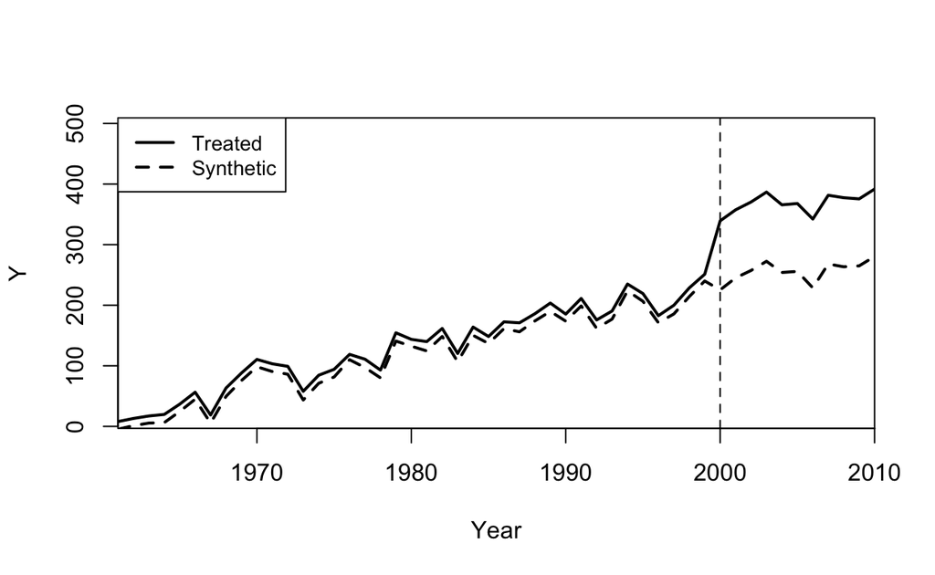

```r
##--Plot treated and synthetic state
path.plot(synth.res    = synth.out,
          dataprep.res = dataprep.out,
          Ylab         = c("Y"),
          Xlab         = c("Year"),
          Legend.position = c("topleft"))

abline(v   = year_policy,
       lty = 2)
```

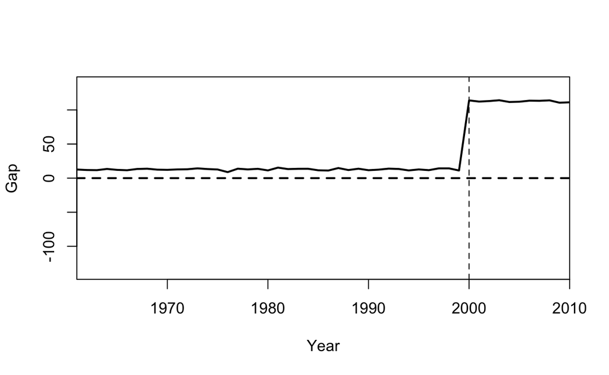

```r
##--Plot gap between treated and synthetic state
gaps.plot(synth.res    = synth.out,
          dataprep.res = dataprep.out,
          Ylab         = c("Gap"),
          Xlab         = c("Year"),
          Main         = ""
)
abline(v   = year_policy,
       lty = 2)
```

Now were going to see how to this manually

# Preliminary notions (regression modeling through matrix multiplication and optimization)

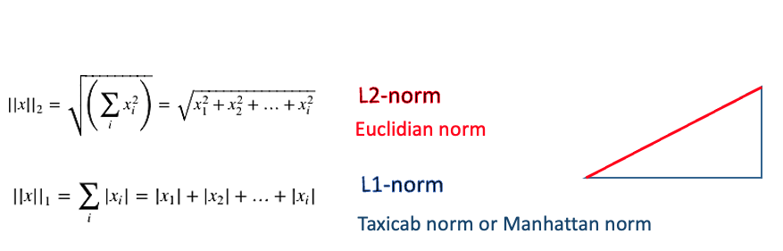

```r
#simulate some data
set.seed(1)
x <- matrix(rbinom(1000, 1, prob=0.3), nrow=100, ncol=1, byrow=T)
y <- matrix(rnorm(1000, 2 + 3*x, sd=1), nrow=100, ncol=1, byrow=F)
int <- rep(1,length(y))
xint <- cbind(int,x)
xint
```

```
       int
  [1,]   1 0
  [2,]   1 0
  [3,]   1 0
  [4,]   1 1
  [5,]   1 0
  [6,]   1 1
  [7,]   1 1
  [8,]   1 0
  [9,]   1 0
 [10,]   1 0
 [11,]   1 0
 [12,]   1 0
 [13,]   1 0
 [14,]   1 0
```

[output cut: 86 more lines]

```r
#Method 1: Ordinary Least Squares (OLS) through simple linear regression
mod1 <- lm(y~x)
tidy(mod1)
```

```
# A tibble: 2 × 5
  term        estimate std.error statistic  p.value
  <chr>          <dbl>     <dbl>     <dbl>    <dbl>
1 (Intercept)     1.95     0.118      16.6 3.65e-30
2 x               3.02     0.208      14.5 4.28e-26
```

```r
#Method 2: Ordinary Least Squares (OLS) through optimzation
p_load("CVXR")
n <- ncol(xint)
beta <- Variable(n)
objective <- Minimize(p_norm((y - xint%*%beta), p=2))
prob <- Problem(objective)
CVXR_result <- solve(prob)
cvxrBeta <- CVXR_result$getValue(beta)
cvxrBeta
```

```
         [,1]
[1,] 1.950601
[2,] 3.015250
```

# Manual Synthetic Control Method

## Step 1: Aggregate data by state, treated and post and transpose the data to obtain a unique row per state

```r
df00 <- mydata %>%
  select(state, treated, post,
         xit, xt, xi, y) %>%
  group_by(state, treated, post) %>%
  group_modify(~ {.x %>% map_dfr(mean)}) %>% #short way to get the aggregated mean
  pivot_wider(names_from = post,
              names_sep = "_",
              values_from = c(treated,
                              xit, xt, xi, y)) %>%
  ungroup() %>%
  rename(treated=treated_0) %>%
  select(-c(treated_1)) %>%
  mutate(y_diff = y_1 - y_0)

df00 %>%
  paged_table()
```

| state | treated | xit_0 | xit_1 | xt_0 | xt_1 | xi_0 | xi_1 | y_0 | y_1 | y_diff |
| --- | --- | --- | --- | --- | --- | --- | --- | --- | --- | --- |
| Alabama | 1 | 24.2298439 | 54.2807686 | 11.0561 | 23.45749 | 7.2533185 | 7.2533185 | 129.160780 | 368.67803 | 239.517251 |
| Alaska | 1 | -11.9378756 | -26.7437572 | 11.0561 | 23.45749 | 6.9714532 | 6.9714532 | 20.705702 | 125.45651 | 104.750812 |
| Arizona | 1 | 6.8870098 | 15.4285842 | 11.0561 | 23.45749 | 6.9571295 | 6.9571295 | 75.497197 | 250.78086 | 175.283663 |
| Arkansas | 1 | 13.4276477 | 30.0812106 | 11.0561 | 23.45749 | 8.3686023 | 8.3686023 | 92.444067 | 291.72911 | 199.285043 |
| California | 1 | 1.2841870 | 2.8768926 | 11.0561 | 23.45749 | 6.7742290 | 6.7742290 | 56.928250 | 211.51492 | 154.586667 |
| Colorado | 0 | 8.0235666 | 17.9747491 | 11.0561 | 23.45749 | 3.5164706 | 3.5164706 | 68.488961 | 147.89270 | 79.403744 |
| Connecticut | 0 | 8.9558344 | 20.0632566 | 11.0561 | 23.45749 | 0.4512472 | 0.4512472 | 70.945488 | 154.51831 | 83.572823 |
| Delaware | 0 | 3.6110962 | 8.0897375 | 11.0561 | 23.45749 | 2.5846137 | 2.5846137 | 54.150038 | 117.26964 | 63.119605 |
| Florida | 0 | -25.6442536 | -57.4493918 | 11.0561 | 23.45749 | 2.1238542 | 2.1238542 | -30.110768 | -75.49433 | -45.383558 |
| Georgia | 0 | 34.9303370 | 78.2524868 | 11.0561 | 23.45749 | 2.2159416 | 2.2159416 | 147.996238 | 327.33056 | 179.334317 |

[output cut: 40 more lines]

## Step 2: Obtain the weights through optimization

```r
p_load("CVXR") #optimization package: convex optimzation

##--Obtaining the value of the xit variable for treated and control
cov_treat <- df00 %>%
  ungroup() %>%
  filter(state=="Alabama") %>% #to do one treated state at a time
  select(xit_0) %>%
  as.matrix() %>%
  t()
cov_treat
```

```
          [,1]
xit_0 24.22984
```

```r
dim(cov_treat)
```

```
[1] 1 1
```

```r
cov_treat %>% t()
```

```
        xit_0
[1,] 24.22984
```

```r
cov_ctrl <- df00 %>%
  ungroup() %>%
  filter(treated==0) %>%
  select(xit_0) %>%
  as.matrix() %>%
  t()

cov_ctrl
```

```
          [,1]     [,2]     [,3]      [,4]     [,5]     [,6]     [,7]
xit_0 8.023567 8.955834 3.611096 -25.64425 34.93034 1.539619 11.83901
          [,8]     [,9]    [,10]   [,11]    [,12]     [,13]    [,14]
xit_0 7.300421 16.33013 13.84078 1.48558 8.555855 -7.360254 14.31292
          [,15]    [,16]     [,17]     [,18]    [,19]    [,20]
xit_0 -1.535662 33.07024 -15.84563 -1.571123 13.93361 10.14274
          [,21]     [,22]   [,23]    [,24]     [,25]    [,26]
xit_0 -3.080196 -7.978005 5.74569 3.836311 -17.51991 4.423838
         [,27]    [,28]     [,29]    [,30]    [,31]    [,32]
xit_0 6.295892 6.109457 -8.678301 9.733897 20.58577 9.494636
          [,33]     [,34]    [,35]     [,36]    [,37]    [,38]
xit_0 -9.647179 -1.230311 8.170281 -3.772414 -21.9375 14.64154
          [,39]     [,40]    [,41]     [,42]    [,43]     [,44]
xit_0 -5.966172 -2.888747 22.09288 -5.300793 14.17834 -11.15145
           [,45]
xit_0 -0.2550407
```

```r
dim(cov_ctrl)
```

```
[1]  1 45
```

```r
cov_ctrl %>% t()
```

```
            xit_0
 [1,]   8.0235666
 [2,]   8.9558344
 [3,]   3.6110962
 [4,] -25.6442536
 [5,]  34.9303370
 [6,]   1.5396194
 [7,]  11.8390069
 [8,]   7.3004213
 [9,]  16.3301316
[10,]  13.8407751
[11,]   1.4855798
[12,]   8.5558545
[13,]  -7.3602541
[14,]  14.3129225
```

[output cut: 31 more lines]

**obtaining the weights through optimization** The SCM is formed by finding the vector of weights `W` that minimizes the imbalance between the treated unit and weighted average of the controls across a set of variables `C` (e.g. pre-intervention covariates) Essentially, in a SCM we try to find W such that $(C_{1} - C_{0}W)'V(C_1- C_0W)$ is minimized `W` being positive and summing to 1 to avoid extrapolating (Abadie et al 2010).

```r
v <- Variable(c(ncol(cov_ctrl), ncol(cov_treat)))
obj <- p_norm((cov_treat - cov_ctrl%*%v), p=2)
#obj <- norm2(cov_treat - cov_ctrl%*%v) #same as above
objective <- Minimize(obj)
prob <- Problem(objective, list(v>=0, sum(v)==1)) #we add in the constraints
CVXR_result <- solve(prob)
synth_weights <- CVXR_result$getValue(v)
round(synth_weights,3)
```

```
       [,1]
 [1,] 0.009
 [2,] 0.010
 [3,] 0.007
 [4,] 0.005
 [5,] 0.614
 [6,] 0.011
 [7,] 0.012
 [8,] 0.009
 [9,] 0.017
[10,] 0.014
[11,] 0.011
[12,] 0.009
[13,] 0.003
[14,] 0.014
```

[output cut: 31 more lines]

```r
##--comparing the weights with those of the synthetic control package
cbind(round(synth_weights,3), synth.tables$tab.w)
```

```
   round(synth_weights, 3) w.weights     unit.names unit.numbers
6                    0.009     0.011       Colorado            6
7                    0.010     0.011    Connecticut            7
8                    0.007     0.009       Delaware            8
9                    0.005     0.001        Florida            9
10                   0.614     0.573        Georgia           10
11                   0.011     0.008         Hawaii           11
12                   0.012     0.013          Idaho           12
13                   0.009     0.011       Illinois           13
14                   0.017     0.016        Indiana           14
15                   0.014     0.014           Iowa           15
16                   0.011     0.008         Kansas           16
17                   0.009     0.011       Kentucky           17
18                   0.003     0.005      Louisiana           18
19                   0.014     0.015          Maine           19
```

[output cut: 31 more lines]

## Step 3: Applying the weights to check covariate balance

```r
#the difference in covariates after applying the weights is essentially 0 as
# expected before the policy
cov_treat - weighted.mean(as.numeric(cov_ctrl), w = synth_weights)
```

```
              [,1]
xit_0 1.922018e-12
```

```r
cov_treat - cov_ctrl%*%synth_weights #same as above
```

```
              [,1]
xit_0 2.021494e-12
```

## Step 4: Implemented the DID

```r
y_treat_post <- df00 %>%
  ungroup() %>%
  filter(state=="Alabama") %>% #to do one treated state at a time
  select(y_1) %>%
  as.matrix() %>%
  as.vector()
y_treat_post
```

```
[1] 368.678
```

```r
y_ctrl_post <- df00 %>%
  ungroup() %>%
  filter(treated==0) %>%
  select(y_1) %>%
  as.matrix() %>%
  as.vector()
y_ctrl_post
```

```
 [1] 147.89270 154.51831 117.26964 -75.49433 327.33056 107.19228
 [7] 169.37303 138.39119 211.91995 183.99936 104.71990 153.64132
[13]  42.89760 191.67919  86.26285 314.19968 -14.84084  84.11010
[19] 192.50051 158.64387  70.35219  39.73418 131.70138 120.35403
[25] -25.83990 120.16697 139.90981 132.73344  32.92792 157.20287
[31] 231.58559 161.09642  29.28275  86.64039 148.30934  69.65903
[37] -54.07477 191.97713  50.30560  71.10540 247.14427  61.47573
[43] 186.44375  16.19294  86.98736
```

```r
y_treat_pre <- df00 %>%
  ungroup() %>%
  filter(state=="Alabama") %>% #to do one treated state at a time
  select(y_0) %>%
  as.matrix() %>%
  as.vector()
y_treat_pre
```

```
[1] 129.1608
```

```r
y_ctrl_pre <- df00 %>%
  ungroup() %>%
  filter(treated==0) %>%
  select(y_0) %>%
  as.matrix() %>%
  as.vector()
y_ctrl_pre
```

```
 [1]  68.488961  70.945488  54.150038 -30.110768 147.996238  52.199152
 [7]  75.561456  61.883550 101.652372  83.096053  49.474320  71.646378
[13]  20.459287  89.197392  42.487115 142.011858  -5.587741  40.252110
[19]  91.240536  71.680470  32.363465  19.730131  60.939582  56.906084
[25]  -9.952884  53.965682  67.078496  60.889841  15.645527  72.121307
[31] 105.250779  76.953271  15.358697  42.231938  68.160350  33.930093
[37] -22.272858  88.428613  22.862277  32.694923 115.340790  31.942144
[43]  84.283573   8.409634  38.703184
```

```r
diff_post = y_treat_post - weighted.mean(y_ctrl_post, w = synth_weights)
#diff_post = y_treat_post - y_ctrl_post%*%synth_weights
diff_post
```

```
[1] 112.6656
```

```r
diff_pre = y_treat_pre - weighted.mean(y_ctrl_pre, w = synth_weights)
#diff_pre = y_treat_pre - y_ctrl_pre%*%synth_weights
diff_pre
```

```
[1] 12.70763
```

```r
DID = diff_post - diff_pre
DID
```

```
[1] 99.95793
```

```r
#Alternatively we can do the following
DID1 <- (weighted.mean(y_treat_post, w = 1) -
           weighted.mean(y_ctrl_post, w = synth_weights)) -

  (weighted.mean(y_treat_pre, w = 1) -
     weighted.mean(y_ctrl_pre, w = synth_weights))
DID1
```

```
[1] 99.95793
```

## Step 5:Or fit a weighted regression model

```r
myweights <- c(1, synth_weights) # weight of 1 for the treated group
myweights %>%
  kable()
```

| x |
| --- |
| 1.0000000 |
| 0.0090121 |
| 0.0096634 |
| 0.0074299 |
| 0.0047911 |
| 0.6138776 |
| 0.0111023 |
| 0.0120323 |
| 0.0085661 |
| 0.0166587 |
| 0.0139479 |
| 0.0114413 |
| 0.0093752 |
| 0.0027230 |
| 0.0144331 |
| 0.0084991 |
| 0.0008568 |
| 0.0040948 |
| 0.0082680 |
| 0.0140423 |
| 0.0105812 |
| 0.0040061 |
| 0.0028378 |
| 0.0078816 |
| 0.0074094 |
| 0.0042567 |
| 0.0074567 |
| 0.0080866 |
| 0.0080248 |
| 0.0029787 |
| 0.0102553 |
| 0.0221831 |
| 0.0100692 |
| 0.0031742 |
| 0.0111591 |
| 0.0091096 |
| 0.0033913 |
| 0.0045848 |
| 0.0147787 |
| 0.0025932 |
| 0.0042485 |
| 0.0243697 |
| 0.0027420 |
| 0.0142935 |
| 0.0034544 |
| 0.0152591 |

```r
df00a <- df00 %>%
  filter(state=="Alabama" | treated == 0) %>%
  mutate(weights = myweights)

paged_table(head(df00a,20))
```

| state | treated | xit_0 | xit_1 | xt_0 | xt_1 | xi_0 | xi_1 | y_0 | y_1 | y_diff | weights |
| --- | --- | --- | --- | --- | --- | --- | --- | --- | --- | --- | --- |
| Alabama | 1 | 24.229844 | 54.280769 | 11.0561 | 23.45749 | 7.2533185 | 7.2533185 | 129.160780 | 368.67803 | 239.517251 | 1.0000000000 |
| Colorado | 0 | 8.023567 | 17.974749 | 11.0561 | 23.45749 | 3.5164706 | 3.5164706 | 68.488961 | 147.89270 | 79.403744 | 0.0090120836 |
| Connecticut | 0 | 8.955834 | 20.063257 | 11.0561 | 23.45749 | 0.4512472 | 0.4512472 | 70.945488 | 154.51831 | 83.572823 | 0.0096633535 |
| Delaware | 0 | 3.611096 | 8.089738 | 11.0561 | 23.45749 | 2.5846137 | 2.5846137 | 54.150038 | 117.26964 | 63.119605 | 0.0074299415 |
| Florida | 0 | -25.644254 | -57.449392 | 11.0561 | 23.45749 | 2.1238542 | 2.1238542 | -30.110768 | -75.49433 | -45.383558 | 0.0047910986 |
| Georgia | 0 | 34.930337 | 78.252487 | 11.0561 | 23.45749 | 2.2159416 | 2.2159416 | 147.996238 | 327.33056 | 179.334317 | 0.6138775917 |
| Hawaii | 0 | 1.539619 | 3.449124 | 11.0561 | 23.45749 | 2.3796395 | 2.3796395 | 52.199152 | 107.19228 | 54.993132 | 0.0111023030 |
| Idaho | 0 | 11.839007 | 26.522267 | 11.0561 | 23.45749 | 1.4976765 | 1.4976765 | 75.561456 | 169.37303 | 93.811574 | 0.0120323448 |
| Illinois | 0 | 7.300421 | 16.354727 | 11.0561 | 23.45749 | 1.6667926 | 1.6667926 | 61.883550 | 138.39119 | 76.507643 | 0.0085660763 |
| Indiana | 0 | 16.330132 | 36.583483 | 11.0561 | 23.45749 | 0.9814246 | 0.9814246 | 101.652372 | 211.91995 | 110.267580 | 0.0166586729 |

[output cut: 10 more lines]

```r
#Crude model
res_model <- glm(y_diff ~ treated , family=gaussian("identity"),
                 data=df00a)
tidy(res_model) %>% mutate_if(is.numeric, round, 2) %>% flextable()
```

| term | estimate | std.error | statistic | p.value |
| --- | --- | --- | --- | --- |
| (Intercept) | 62.86 | 7.01 | 8.97 | 0 |
| treated | 176.65 | 47.55 | 3.72 | 0 |

```r
#Conditional adjusted Model without weighting
res_model <- glm(y_diff ~ treated + xit_0 , family=gaussian("identity"),
                 data=df00a)
tidy(res_model) %>% mutate_if(is.numeric, round, 2) %>% flextable()
```

| term | estimate | std.error | statistic | p.value |
| --- | --- | --- | --- | --- |
| (Intercept) | 49.51 | 0.05 | 1,025.87 | 0 |
| treated | 100.02 | 0.32 | 308.93 | 0 |
| xit_0 | 3.71 | 0.00 | 1,002.48 | 0 |

```r
#Marginal adjusted Model with weighting
res_model <- glm(y_diff ~ treated, family=gaussian("identity"),
                 data=df00a, weights = myweights)
tidy(res_model) %>% mutate_if(is.numeric, round, 2) %>% flextable()
```

| term | estimate | std.error | statistic | p.value |
| --- | --- | --- | --- | --- |
| (Intercept) | 139.56 | 8.34 | 16.74 | 0 |
| treated | 99.96 | 11.79 | 8.48 | 0 |

```r
#Point estimate is correct but standard error are not: need to use other
#method e.g. bootstrap
```

# Generalized Synthetic Control

For more information about the generalized synthetic control method. You can check out the paper [here](https://www.cambridge.org/core/journals/political-analysis/article/generalized-synthetic-control-method-causal-inference-with-interactive-fixed-effects-models/B63A8BD7C239DD4141C67DA10CD0E4F3). A nice tutorial can be found [here](https://yiqingxu.org/packages/gsynth/articles/tutorial.html)

```r
p_load("gsynth")
y <- gsynth(y ~ treatedpost + xit,
            data = mydata,  EM = F, index = c("state","year"),
            inference = "parametric", se = TRUE,
            nboots = 2,  r = c(0, 5), CV = TRUE, force = "two-way", parallel = FALSE)
```

```
Cross-validating ...
 r = 0; sigma2 = 0.99099; IC = 0.31685; PC = 0.94915; MSPE = 0.94334*
 r = 1; sigma2 = 0.95575; IC = 0.59625; PC = 1.08066; MSPE = 1.00561
 r = 2; sigma2 = 0.91888; IC = 0.86566; PC = 1.19867; MSPE = 1.04163
 r = 3; sigma2 = 0.88434; IC = 1.12923; PC = 1.30810; MSPE = 1.07040
 r = 4; sigma2 = 0.85882; IC = 1.39497; PC = 1.42113; MSPE = 1.10497
 r = 5; sigma2 = 0.83259; IC = 1.65212; PC = 1.52466; MSPE = 1.11968

 r* = 0

Simulating errors ...Bootstrapping ...
```

```r
y1 <- round(data.frame(y$est.avg),2)
y1
```

```
        Estimate S.E. CI.lower CI.upper p.value
ATT.avg    99.98 0.01    99.96   100.01       0
```

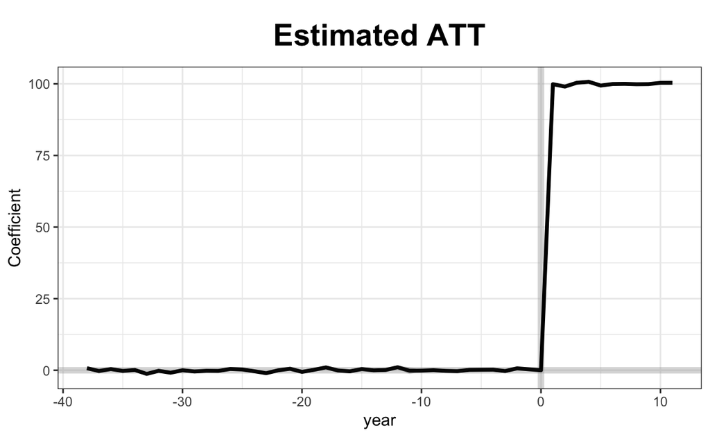

```r
plot(y)
```

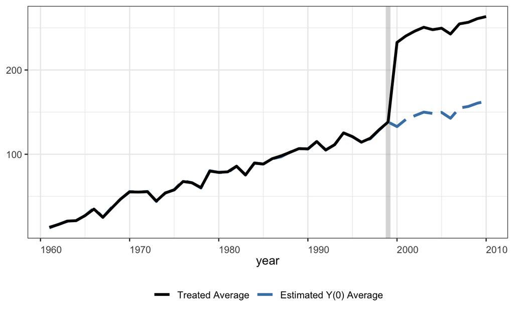

```r
plot(y, type = "counterfactual", raw = "none", main="")
```

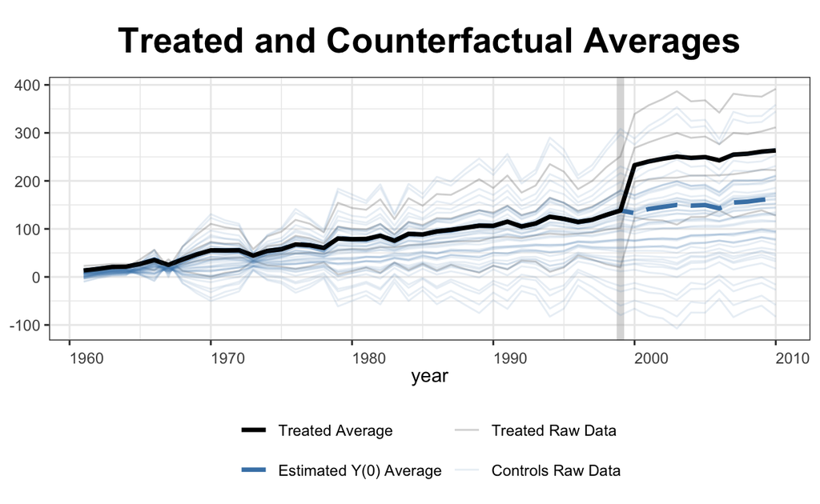

```r
plot(y, type = "counterfactual", raw = "all")
```

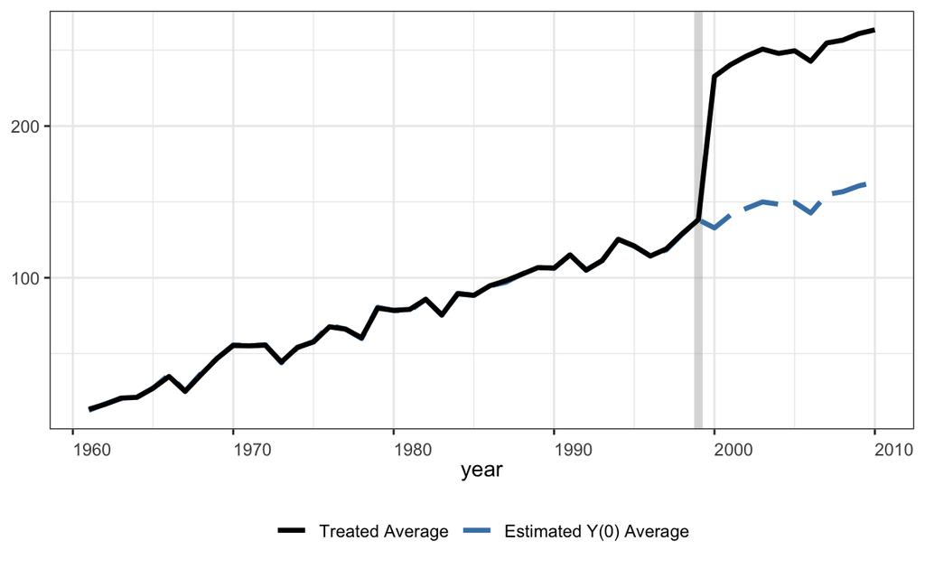

```r
plot(y, type = "ct", raw = "none", main = "", shade.post = FALSE)
```

# Augmented Synthetic control

For more information about the augmented synthetic control method. You can check out the paper [here](https://www.tandfonline.com/doi/abs/10.1080/01621459.2021.1929245?journalCode=uasa20) A nice tutorial can be found [here](https://github.com/ebenmichael/augsynth/blob/master/vignettes/singlesynth-vignette.md)

```r
# ## Install devtools if noy already installed
# install.packages("devtools", repos='http://cran.us.r-project.org')
# Install augsynth from github
# devtools::install_github("ebenmichael/augsynth")

p_load_gh("ebenmichael/augsynth")
set.seed(123)
augsynth.scm <-augsynth(y ~ treatedpost | xit,
                        unit = state,
                        time = year,
                        data = mydata,
                        #t_int = 2000, #not necessary to add
                        fixedeff = T,
                        progfunc="Ridge", scm=T)
```

```
One outcome and one treatment time found. Running single_augsynth.
```

```r
#progfunc = None for Traditional SCM,
#progfunc = Ridge for Ridge regression or augmented SCM
#progfunc = GSYN for the Generalized SCM

augsynth.scm
```

```
Call:
single_augsynth(form = form, unit = !!enquo(unit), time = !!enquo(time),
    t_int = t_int, data = data, progfunc = "Ridge", scm = ..3,
    fixedeff = ..1)

Average ATT Estimate: 99.817
```

```r
res <- summary(augsynth.scm, inf = T,
        inf_type = "jackknife+", #algorithm over time periods
        linear_effect = T)
res
```

```
Call:
single_augsynth(form = form, unit = !!enquo(unit), time = !!enquo(time),
    t_int = t_int, data = data, progfunc = "Ridge", scm = ..3,
    fixedeff = ..1)

Average ATT Estimate:  99.817
L2 Imbalance: 0.032
Percent improvement from uniform weights: 99.9%

Covariate L2 Imbalance: 0.053
Percent improvement from uniform weights: 99.1%

Avg Estimated Bias: 0.064

Inference type: Jackknife+ over time periods

 Time Estimate 95% CI Lower Bound 95% CI Upper Bound
 2000   99.878             96.685            103.711
 2001   98.960             95.210            101.948
 2002  101.484             97.871            105.016
 2003   98.576             95.510            103.971
 2004   98.335             95.618            102.314
 2005   99.795             97.268            104.328
 2006  103.120             98.742            105.233
 2007   99.114             95.733            102.609
 2008   97.713             95.222            101.563
 2009  101.911             98.445            105.101
 2010   99.098             96.219            103.310
```

```r
y2 <- res$average_att
y2
```

```
                          Value Estimate Std.Error lower_bound
1 Average Post-Treatment Effect 99.81669        NA    97.14504
  upper_bound
1    103.2074
```

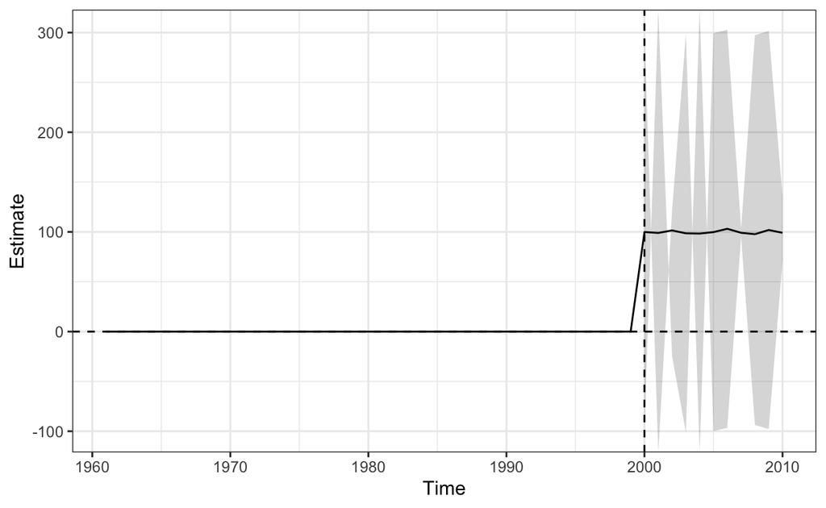

```r
plot_aug <- plot(augsynth.scm)
plot_aug
```

```r
augsynth.scm$weights
```

```
                       [,1]
Colorado       -0.527611902
Connecticut     0.247626247
Delaware       -0.241855516
Florida        -0.011008981
Georgia        -0.228673687
Hawaii         -0.029909862
Idaho           0.131708295
Illinois       -0.434470866
Indiana         0.469528992
Iowa            0.016970349
Kansas          0.177542912
Kentucky        0.201843111
Louisiana       0.410938962
Maine          -0.043518503
Maryland        0.262803968
Massachusetts  -0.105193304
Michigan        0.042338714
Minnesota      -0.178797153
Mississippi     0.294070845
Missouri        0.337526915
Montana         0.160352433
Nebraska       -0.031168196
Nevada          0.091360610
New Hampshire  -0.276604972
New Jersey      0.343193973
New Mexico      0.037435683
New York        0.317618864
North Carolina  0.294139159
North Dakota   -0.222233487
Ohio            0.116955179
Oklahoma       -0.105664909
Oregon          0.275084719
Pennsylvania    0.008126639
Rhode Island    0.311159886
South Carolina  0.231261091
South Dakota   -0.124273244
Tennessee      -0.232731323
Texas          -0.241471980
Utah           -0.224812847
Vermont        -0.128854669
Virginia        0.036680757
Washington     -0.086271158
West Virginia   0.061139130
Wisconsin      -0.135402234
Wyoming        -0.266878638
```

```r
#weights are not necessarily positive

augsynth.scm$l2_imbalance
```

```
[1] 0.03197335
```

```r
#the overall imbalance between the two groups
```